# Data Science Capstone Project Milestone Report

Marvin Zaluski

January 7, 2018

## Data Set Characteristics

The data set used in the project was downloaded from the Coursera site with the following address, https://d396qusza40orc.cloudfront.net/dsscapstone/dataset/Coursera-SwiftKey.zip After unzipping the data file, the corpora are grouped into four distinct languages:

- English
- German
- Finnish
- Russian

Each language has three corpora grouped into the following data sources:

- blogs
- news
- twitter

The following results were obtained using the 12 different corpora.

| Corpus | Filename | Lines | Max Line Length | Average Line Length |
| --- | --- | --- | --- | --- |
| German Blogs | de_DE.blogs.txt | 181,958 | 7,194 | 224 |
| German News | de_DE.news.txt | 244,743 | 3,949 | 382 |
| German Twitter | de_DE.twitter.txt | 947,774 | 140 | 77 |
| English Blogs | en_US.blogs.txt | 899,288 | 40,833 | 230 |
| English News | en_US.news.txt | 77,259 | 5,760 | 202 |
| English Twitter | en_US.twitter.txt | 2,360,148 | 140 | 69 |
| Finnish Blogs | fi_FI.blogs.txt | 439,785 | 18,299 | 234 |
| Finnish News | fi_FI.news.txt | 485,758 | 3,820 | 184 |
| Finnish Twitter | fi_FI.twitter.txt | 285,214 | 140 | 83 |
| Russian Blogs | ru_RU.blogs.txt | 337,100 | 7,806 | 190 |
| Russian News | ru_RU.news.txt | 196,360 | 9,540 | 331 |
| Russian Twitter | ru_RU.twitter.txt | 881,414 | 140 | 66 |

Some early observations about the data are:

- largest number of lines comes from the English Twitter data (2,360,148 lines)
- smallest number of lines comes from the English News data (77,259 lines)
- longest line comes from the English Blogs data (40,833 characters)
- shortest maximum line lengths are from twitter data (140 characters)
- the average longest line lengths belong to German News (382 characters) and Russian News (331 characters)
- the average shortest line length come from twitter data.

This project will focus on the English version of the corpora in the analysis described in the following sections.

## Preprocessing

The following line of data was extracted from the English blogs.

```
## [1] "Chad has been awesome with the kids and holding down the fort while I work later than usual! The kids have been busy together playing Skylander on the XBox together, after Kyan cashed in his $$$ from his piggy bank. He wanted that game so bad and used his gift card from his birthday he has b…
```

This line demonstrates that the data cannot be analyzed without some preprocessing. Special characters could be seen representing punctuation and prefixes/suffixes are used to augment words seen in the text. Also, there is a mixture of upper and lower case letters are exhibited in the data and these situations must be addressed in order to “normalize” the text data.

The following preprocessing was performed on the corpora:

- removal of special characters
- stemming
- conversion to lower case characters

This results in the following result from the above preprocessing.

```
## [1] "chad has been awesom with the kid and hold down the fort while i work later than usual the kid have been busi togeth play skyland on the xbox togeth after kyan cash in his from his piggi bank he want that game so bad and use his gift card from his birthday he has been save and the money to g…
```

These techniques are a small subsample of text preprocessing that can be performed on the data and other text preprocessing techniques may be beneficial before any text analysis is performed.

## N-gram Analysis

The analysis of the frequencies of different frequencies of individual words and combinations of words may lead to some insight into the ability to predict the next word in a sequence of text. This section will focus on the analysis of unigrams and bigrams. The following graphs outline the top 20 unigrams in the entire corpora, blogs, news, and twitter corpora.

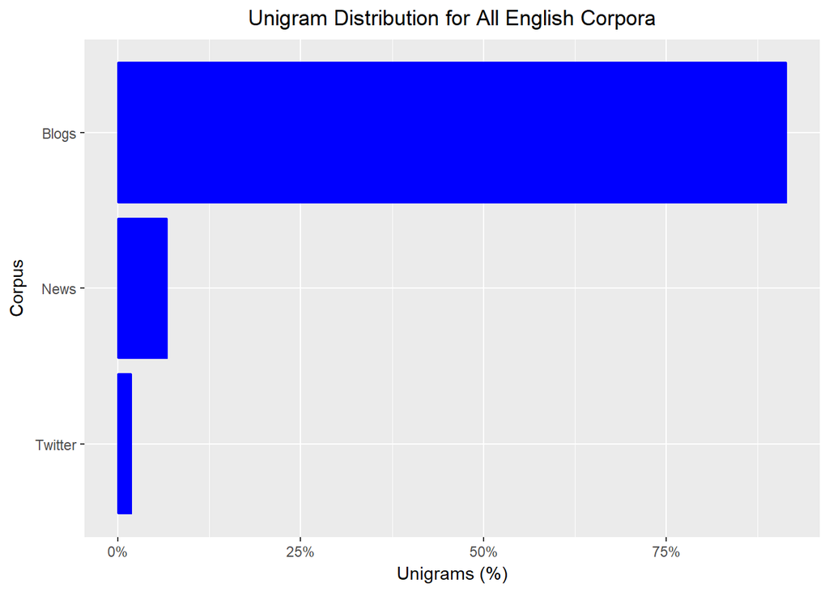

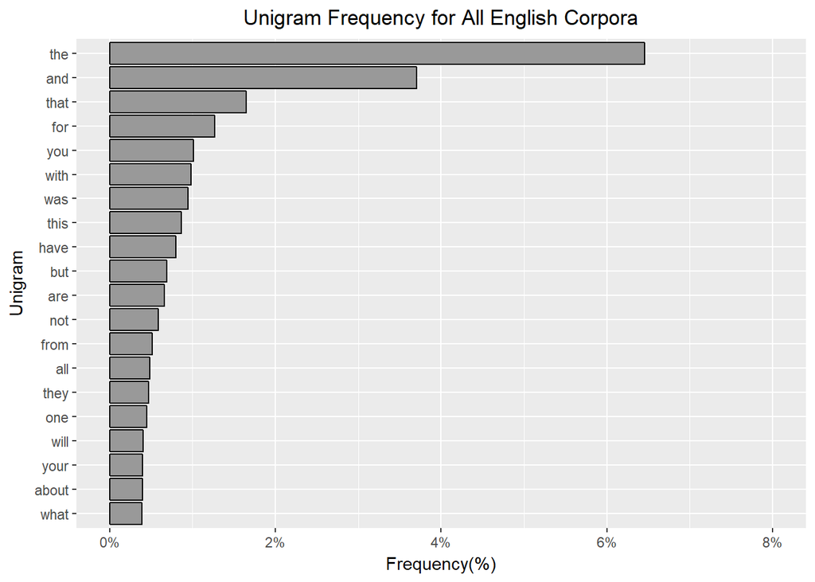

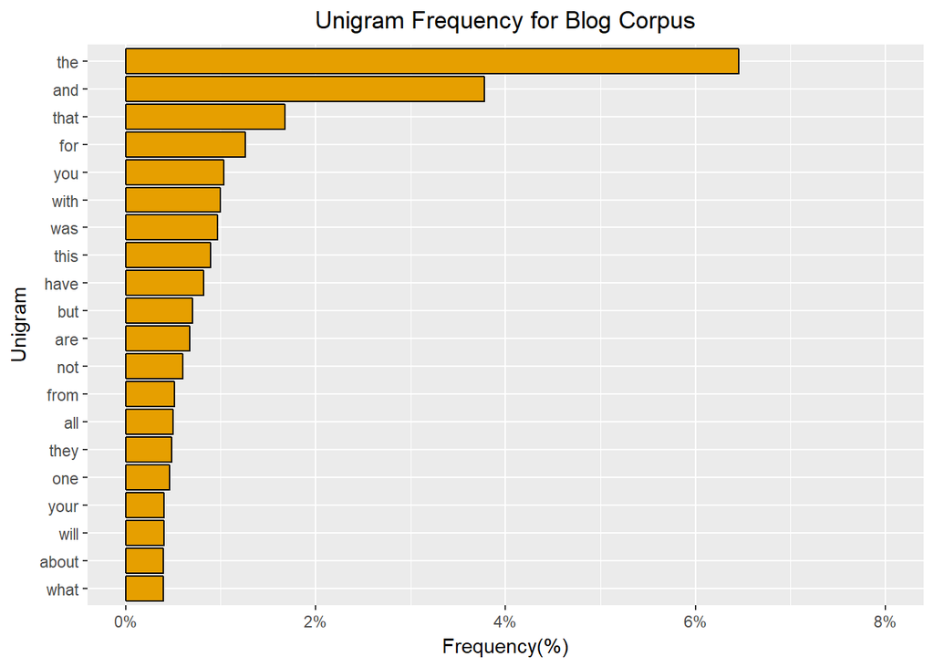

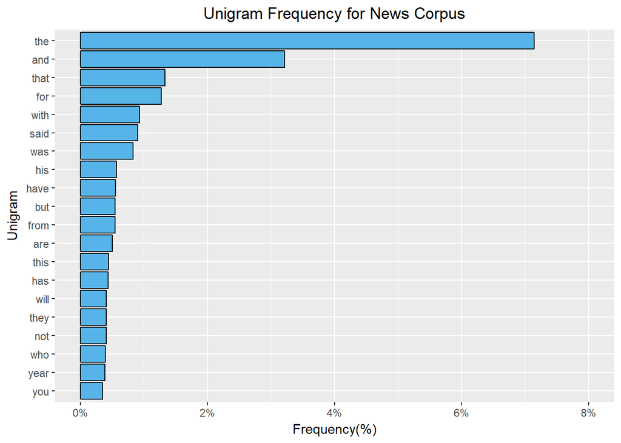

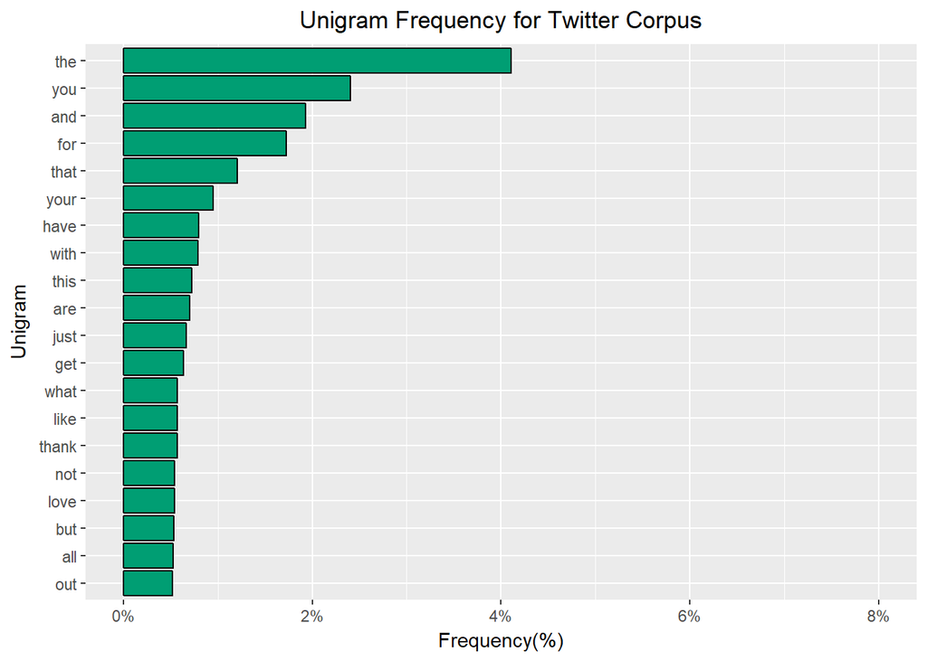

The unigram analysis revealed the following:

- large majority of unigrams come from blogs
- the distribution of unigrams is very similar for the overall corpora and blogs corpus
- some unigrams such as “you” are not as frequent in the news corpus while is more frequent in the twitter corpus
- different unigrams such as “thank” and “love” are frequent in the twitter corpus

A similar analysis was performed with bigrams and the following top 20 bigrams for the same corpora.

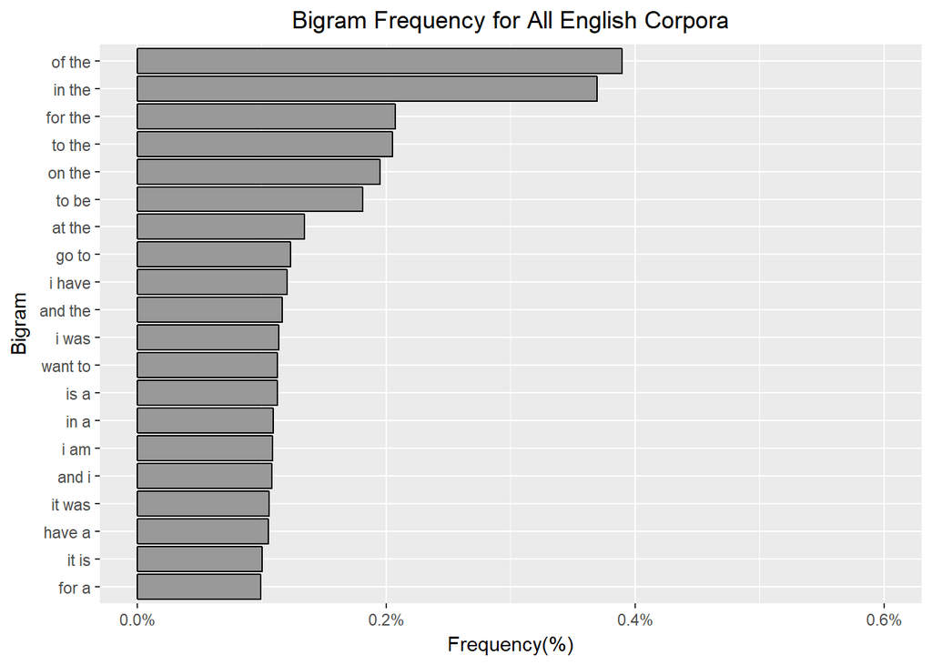

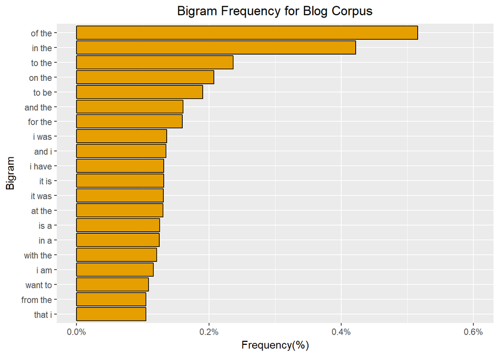

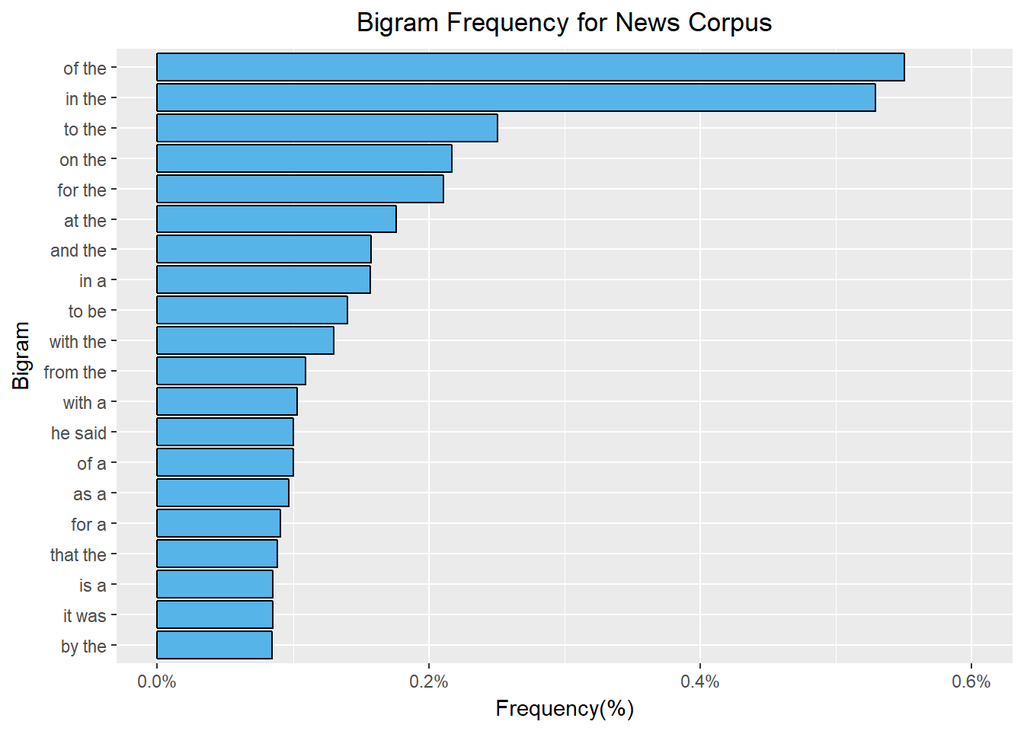

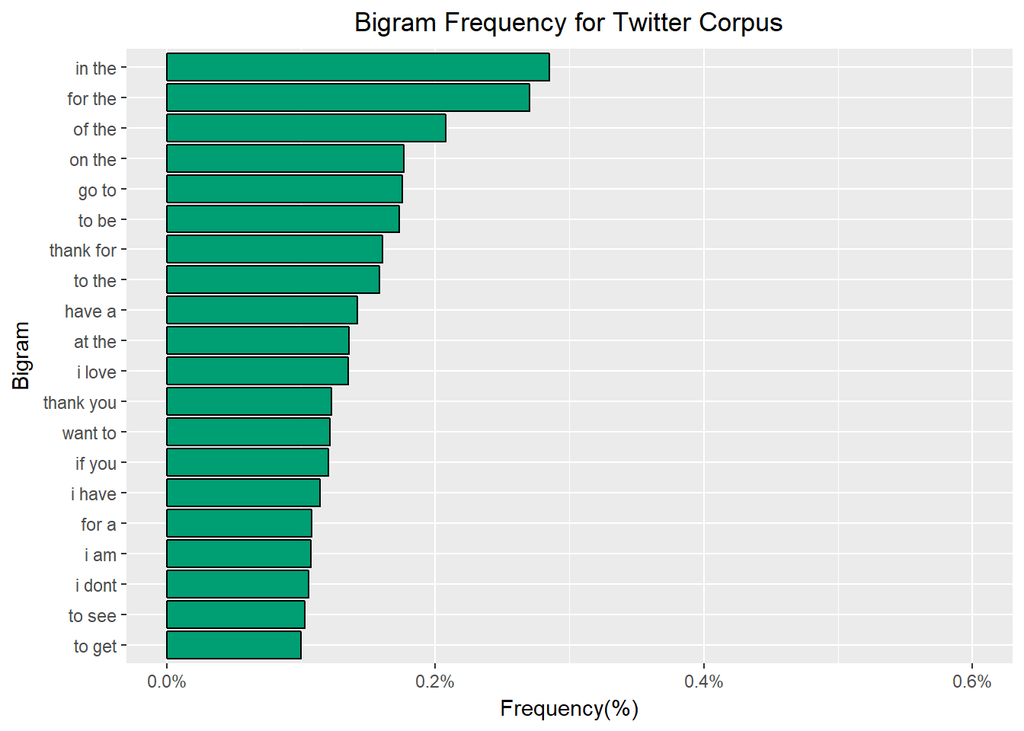

The following was discovered in the bigram analysis:

- similar bigrams were found to be quite frequent in all corpora
- the most frequent unigram “the” was found to be the frequent second word in the bigrams
- “the” is frequently preceeded by a preposition such as “in”, “from”, and “of”.
- labeling the parts of speech may help in predicting the next word.
- the twitter corpus had unique bigrams such as “thank you” and “thanks for” that frequently occurred

## Conclusions and Recommendations

Some of the following conclusions were found:

- preprocessing was important to help normalize the text
- some unigrams and bigrams were frequent in the corpora
- some unigrams and bigrams were uniquely frequent in some corpus; for example “thank” in the twitter corpus.
- parts of speech may be influential in predicting follow on words.

Some of the following recommendations are:

- additional trigram and other ngram analysis.
- incorporation of part of speech tagging for words.
- explore machine learning algorithms such as bayesian networks that use a priori information and probabilities to predict the next word in a sequence.
- explore clustering of the text data to reveal hidden structures.
- evaluate the building of separate prediction models based on the type of corpus.
- use of memory management and processing techniques to handle the large amounts of data.